# Worksheet 8

Published

February 28, 2025

## Packages

```r
library(tidyverse)
library(car)
library(lme4)
```

One not especially long scenario, but you may find yourself with some thinking to do.

## You have intelligent rats

Each of 12 students trained rats to run a maze, and the number of successful runs (out of 50 attempts) was recorded on each of 5 days. Some of the students were told that the rats they were training were “bright” (intelligent) and some of them were told that their rats were “dull” (not intelligent). In actual fact, all the rats were from the same source, and none of them were any more intelligent than the others. Did it make a difference whether the students were told that their rats were intelligent on the number of mazes the rats successfully ran, and, if so, was the effect consistent over time? The same group of rats were trained by the same student throughout this experiment, so it makes sense to treat the data as repeated measures.

The data are in http://ritsokiguess.site/datafiles/intelligent-rats.csv. The columns of interest to us are:

- `Student`: a numerical identifier for each student
- `Treatment`: what the student was told about their rats
- `Day1` through `Day5`: the number of successful runs on each day.

There are some other variables that will not concern us here.

1. Read in and display (some of) the data.

Nothing unexpected here:

```r
my_url <- "http://ritsokiguess.site/datafiles/intelligent-rats.csv"
maze <- read_csv(my_url)
maze
```

| Student | PriorExp | Block | Treatment | Day1 | Day2 | Day3 | Day4 | Day5 | Relax | Success | Slope |
| --- | --- | --- | --- | --- | --- | --- | --- | --- | --- | --- | --- |
| 1 | -7 | 1 | dull | 10 | 13 | 12 | 12 | 9 | 3 | 0.22 | -0.006 |
| 2 | -6 | 1 | bright | 18 | 20 | 21 | 23 | 30 | 9 | 0.45 | 0.054 |
| 3 | -5 | 2 | bright | 16 | 14 | 20 | 20 | 20 | 5 | 0.36 | 0.028 |
| 4 | 1 | 2 | dull | 11 | 20 | 27 | 17 | 16 | 6 | 0.36 | 0.014 |
| 5 | 2 | 3 | bright | 27 | 24 | 26 | 28 | 27 | 10 | 0.53 | 0.008 |
| 6 | 2 | 3 | dull | 16 | 14 | 14 | 13 | 15 | 4 | 0.29 | -0.006 |
| 7 | 3 | 4 | dull | 8 | 10 | 21 | 10 | 20 | 5 | 0.28 | 0.048 |
| 8 | 3 | 4 | bright | 13 | 20 | 18 | 20 | 22 | 7 | 0.37 | 0.036 |
| 9 | 3 | 5 | bright | 24 | 23 | 27 | 29 | 27 | 10 | 0.52 | 0.024 |
| 10 | 7 | 5 | dull | 13 | 12 | 23 | 17 | 16 | 6 | 0.32 | 0.022 |

[output cut: 2 more lines]

2. Set up and run an appropriate repeated-measures ANOVA. What do you conclude from it? (Hint: set up the response variable, and go through the steps required to run the `Manova`. Obtain the appropriate P-values, describing your process.)

There’s actually a fair bit to do here. The first bit is to grab the five `Day` columns and make a response matrix out of them, either this way:

```r
maze %>% select(starts_with("Day")) %>%
  as.matrix() -> response
response
```

```
      Day1 Day2 Day3 Day4 Day5
 [1,]   10   13   12   12    9
 [2,]   18   20   21   23   30
 [3,]   16   14   20   20   20
 [4,]   11   20   27   17   16
 [5,]   27   24   26   28   27
 [6,]   16   14   14   13   15
 [7,]    8   10   21   10   20
 [8,]   13   20   18   20   22
 [9,]   24   23   27   29   27
[10,]   13   12   23   17   16
[11,]    9   15   24   12   11
[12,]   19   17   23   33   29
```

or this way:

```r
response1 <- with(maze, cbind(Day1, Day2, Day3, Day4, Day5))
response1
```

```
      Day1 Day2 Day3 Day4 Day5
 [1,]   10   13   12   12    9
 [2,]   18   20   21   23   30
 [3,]   16   14   20   20   20
 [4,]   11   20   27   17   16
 [5,]   27   24   26   28   27
 [6,]   16   14   14   13   15
 [7,]    8   10   21   10   20
 [8,]   13   20   18   20   22
 [9,]   24   23   27   29   27
[10,]   13   12   23   17   16
[11,]    9   15   24   12   11
[12,]   19   17   23   33   29
```

The second way is more like what I did in class, but also more typing. The `as.matrix` turns a dataframe into a `matrix`, which is what the response needs to be in the end.

Next, run `lm`, set up the time-dependence stuff, run `Manova`, and look at the results. This is basically cookie-cutter code: take what appears in the lecture notes and copy and paste it, changing a few names:

```r
maze.1 <- lm(response ~ Treatment, data = maze)
times <- colnames(response)
times.df <- data.frame(times = factor(times))
maze.2 <- Manova(maze.1, idata = times.df, idesign = ~ times)
summary(maze.2)
```

```
Type II Repeated Measures MANOVA Tests:

------------------------------------------

Term: (Intercept)

 Response transformation matrix:
     (Intercept)
Day1           1
Day2           1
Day3           1
Day4           1
Day5           1

Sum of squares and products for the hypothesis:
            (Intercept)
(Intercept)    104160.3

Multivariate Tests: (Intercept)
                 Df test stat approx F num Df den Df     Pr(>F)
Pillai            1   0.97802 444.8761      1     10 1.2754e-09 ***
Wilks             1   0.02198 444.8761      1     10 1.2754e-09 ***
Hotelling-Lawley  1  44.48761 444.8761      1     10 1.2754e-09 ***
Roy               1  44.48761 444.8761      1     10 1.2754e-09 ***
---
Signif. codes:  0 '***' 0.001 '**' 0.01 '*' 0.05 '.' 0.1 ' ' 1

------------------------------------------

Term: Treatment

 Response transformation matrix:
     (Intercept)
Day1           1
Day2           1
Day3           1
Day4           1
Day5           1

Sum of squares and products for the hypothesis:
```

[output cut: 83 more lines]

```
Treatment:times        0.69814 0.96424


Greenhouse-Geisser and Huynh-Feldt Corrections
 for Departure from Sphericity

                 GG eps Pr(>F[GG])
times           0.86937  0.0004321 ***
Treatment:times 0.86937  0.0052136 **
---
Signif. codes:  0 '***' 0.001 '**' 0.01 '*' 0.05 '.' 0.1 ' ' 1

                  HF eps   Pr(>F[HF])
times           1.389507 0.0001909378
Treatment:times 1.389507 0.0032260394
```

Finally, go down to near the bottom and check the sphericity tests. Sphericity is by no means rejected (P-value 0.964), so look at the “Univariate Type II Repeated-Measures ANOVA Assuming Sphericity” just above that. The interaction is significant, with a P-value of 0.0032, so that is our finding. In the context of the data, that means that there is an effect of treatment on the number of successful runs, but that effect depends on which day you are looking at. (This is as far as we can go for now.)

3. Draw a suitable interaction plot (for treatment and time). How does this clarify your conclusions of the previous part? (Hint: you’ll need longer data. If you want to be consistent with me, use `Day` for the names of the days, and `runs` for the numbers of runs.)

The hint says that the first thing we need to do is to make “longer” data, with each observation on one row:[^1]

```r
maze %>%
  pivot_longer(starts_with("Day"), names_to = "Day", values_to = "runs") -> maze_long
maze_long
```

| Student | PriorExp | Block | Treatment | Relax | Success | Slope | Day | runs |
| --- | --- | --- | --- | --- | --- | --- | --- | --- |
| 1 | -7 | 1 | dull | 3 | 0.22 | -0.006 | Day1 | 10 |
| 1 | -7 | 1 | dull | 3 | 0.22 | -0.006 | Day2 | 13 |
| 1 | -7 | 1 | dull | 3 | 0.22 | -0.006 | Day3 | 12 |
| 1 | -7 | 1 | dull | 3 | 0.22 | -0.006 | Day4 | 12 |
| 1 | -7 | 1 | dull | 3 | 0.22 | -0.006 | Day5 | 9 |
| 2 | -6 | 1 | bright | 9 | 0.45 | 0.054 | Day1 | 18 |
| 2 | -6 | 1 | bright | 9 | 0.45 | 0.054 | Day2 | 20 |
| 2 | -6 | 1 | bright | 9 | 0.45 | 0.054 | Day3 | 21 |
| 2 | -6 | 1 | bright | 9 | 0.45 | 0.054 | Day4 | 23 |
| 2 | -6 | 1 | bright | 9 | 0.45 | 0.054 | Day5 | 30 |

[output cut: 50 more lines]

Then work out the mean number of runs for each combination of `Treatment` and `Day`:

```r
maze_long %>%
  group_by(Treatment, Day) %>%
  summarize(mean_runs = mean(runs)) -> means
means
```

| Treatment | Day | mean_runs |
| --- | --- | --- |
| bright | Day1 | 19.50000 |
| bright | Day2 | 19.66667 |
| bright | Day3 | 22.50000 |
| bright | Day4 | 25.50000 |
| bright | Day5 | 25.83333 |
| dull | Day1 | 11.16667 |
| dull | Day2 | 14.00000 |
| dull | Day3 | 20.16667 |
| dull | Day4 | 13.50000 |
| dull | Day5 | 14.50000 |

And then make the interaction plot, bearing in mind that you need a `colour` and a `group` and they need to be *the same*:

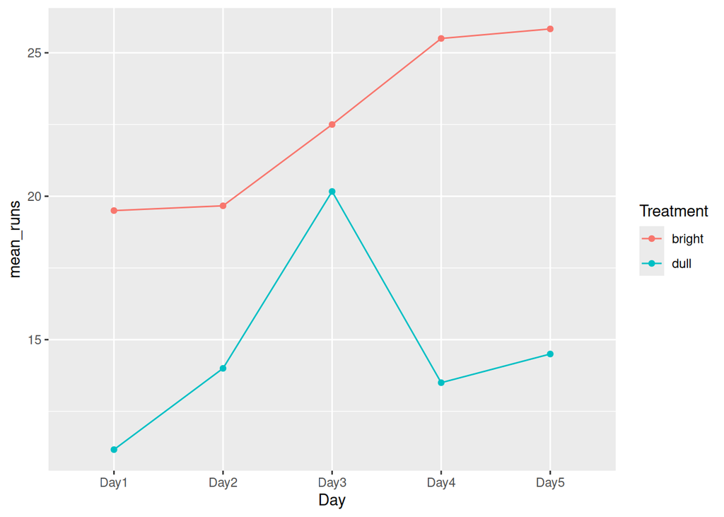

```r
ggplot(means, aes(x = Day, y = mean_runs, colour = Treatment, group = Treatment)) +
  geom_point() + geom_line()
```

(You don’t need to display the intervening dataframes, though you probably should for yourself while you’re working on this.)

When the students were told that their rats were “bright”, the number of successful runs on average increased over time. But for the students told that their rats were “dull”, the mean number of successful runs increased up to day 3, peaked there, and decreased afterwards. You might also say that the traces over time are not parallel, and talk about how they are not.

This difference in pattern over time was the reason for the significant interaction.

Extra: I also drew a spaghetti plot, which uses the same long data that we just made, but has a `colour` and `group` that are *different*. The lines on this one need to join observations that come from the same *student*, so that’s what goes in `group`:

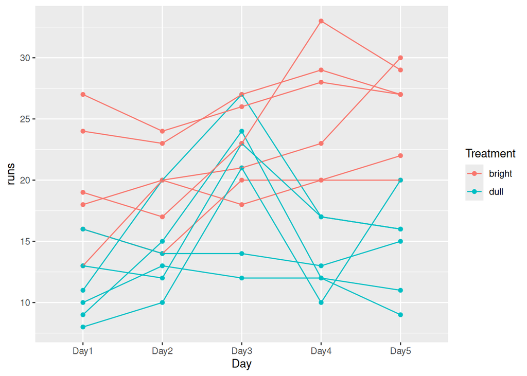

```r
ggplot(maze_long, aes(x = Day, y = runs, colour = Treatment, group = Student)) +
  geom_point() + geom_line()
```

The pattern is not so clear here (which is why I had you draw the interaction plot instead), but if you look carefully, you can that several of the students with the supposedly “dull” rats had the number of successful runs peak at day 3, while the students with “bright” rats saw the number of runs on a more or less upward trajectory. There is some variability here, but the different patterns over time were consistent enough to make the interaction strongly significant.

The red traces are mostly above the blue ones (except perhaps at day 3), which is probably the reason there is a significant treatment main effect, but we would do better to look at simple effects over time to further understand the significant interaction (the treatment effect will probably not be consistent over time, as a consequence of the significant interaction).

4. For each time point (day), run a simple effects analysis: that is, using an ordinary `aov`, test whether the number of successful runs depends on whether the rat was labelled as “dull” or “bright”.

I think I airily talked about how you can use simple effects to understand an interaction in this kind of analysis, but never actually showed you an example. There are two ways you might go:

- fix time and look at the effect of treatment at each time
- fix treatment and look at the effect of time within that treatment

In this example, and perhaps more generally, the first option makes more sense to me: we care more about the treatment effect, while the time is a sort of “block” within which to observe the treatment effect. The first option is also easier to do, because by focusing on only one time point at a time, there is no time dependence left and each student gives you only one observation at that time (the number of runs their rats made at that time). Hence, the analysis at each time point is only an ordinary `aov`.[^2]

Last year, I had this as an Extra on an assignment (where students had to do the MANOVA-based approach above). In my solutions then, I used the longer dataframe that you made above to draw the interaction plot with, but thinking about it now, it actually goes more easily with the original wider data: pick out the day of interest, see whether the number of mazes completed that day depends on treatment, and then repeat for the other days.

Here’s day 1:

```r
d.1 <- aov(Day1 ~ Treatment, data = maze)
summary(d.1)
```

```
            Df Sum Sq Mean Sq F value  Pr(>F)
Treatment    1  208.3  208.33   11.81 0.00636 **
Residuals   10  176.3   17.63
---
Signif. codes:  0 '***' 0.001 '**' 0.01 '*' 0.05 '.' 0.1 ' ' 1
```

There is a treatment effect (P-value 0.006) on Day 1, which we know (from the interaction plot) is because the supposedly `bright` rats performed better than the `dull` ones. This is all we need to do for Day 1, because there were only two treatments, and we now know that they were significantly different in terms of mazes run (and we know from our graph which way around the difference is). If there had been *three* treatments, say a third one in which the students were told nothing about their rats, then we would run `TukeyHSD` to find out which treatments differed from which on Day 1. But there is no need for that here.

We would expect something similar to happen on Day 2. Copy, paste, and edit:

```r
d.2 <- aov(Day2 ~ Treatment, data = maze)
summary(d.2)
```

```
            Df Sum Sq Mean Sq F value Pr(>F)
Treatment    1  96.33   96.33   7.565 0.0205 *
Residuals   10 127.33   12.73
---
Signif. codes:  0 '***' 0.001 '**' 0.01 '*' 0.05 '.' 0.1 ' ' 1
```

Still significant (P-value 0.020), though not as strongly so. The `bright` rats (so-called) again did better than the `dull` ones.

Day 3 is where the significance of the treatment effect might go away, since this is where the `dull` rats peaked. Paste again (it is probably still on your clipboard):

```r
d.3 <- aov(Day3 ~ Treatment, data = maze)
summary(d.3)
```

```
            Df Sum Sq Mean Sq F value Pr(>F)
Treatment    1  16.33   16.33   0.691  0.425
Residuals   10 236.33   23.63
```

The P-value is 0.425, which is nowhere near significance, so there is no treatment effect on Day 3.

After that, you would expect `bright` to be better again, since the `dull` rats peaked and the `bright` ones continued to improve after Day 3:

```r
d.4 <- aov(Day4 ~ Treatment, data = maze)
summary(d.4)
```

```
            Df Sum Sq Mean Sq F value   Pr(>F)
Treatment    1    432   432.0   23.61 0.000663 ***
Residuals   10    183    18.3
---
Signif. codes:  0 '***' 0.001 '**' 0.01 '*' 0.05 '.' 0.1 ' ' 1
```

```r
d.5 <- aov(Day5 ~ Treatment, data = maze)
summary(d.5)
```

```
            Df Sum Sq Mean Sq F value   Pr(>F)
Treatment    1  385.3   385.3   24.65 0.000566 ***
Residuals   10  156.3    15.6
---
Signif. codes:  0 '***' 0.001 '**' 0.01 '*' 0.05 '.' 0.1 ' ' 1
```

And so it proves, with P-values 0.00066 and 0.00057. Thus, there is a significant treatment effect on all the days except Day 3. This (small) inconsistency of pattern is what drives the significant interaction; if the interaction had not been significant, there would have been a consistent treatment effect over all five days.[^3]

5. Do a mixed model analysis (hint: use the long data that you made for your interaction plot.)

Let’s remind ourselves of how the longer data looked:

```r
maze_long
```

| Student | PriorExp | Block | Treatment | Relax | Success | Slope | Day | runs |
| --- | --- | --- | --- | --- | --- | --- | --- | --- |
| 1 | -7 | 1 | dull | 3 | 0.22 | -0.006 | Day1 | 10 |
| 1 | -7 | 1 | dull | 3 | 0.22 | -0.006 | Day2 | 13 |
| 1 | -7 | 1 | dull | 3 | 0.22 | -0.006 | Day3 | 12 |
| 1 | -7 | 1 | dull | 3 | 0.22 | -0.006 | Day4 | 12 |
| 1 | -7 | 1 | dull | 3 | 0.22 | -0.006 | Day5 | 9 |
| 2 | -6 | 1 | bright | 9 | 0.45 | 0.054 | Day1 | 18 |
| 2 | -6 | 1 | bright | 9 | 0.45 | 0.054 | Day2 | 20 |
| 2 | -6 | 1 | bright | 9 | 0.45 | 0.054 | Day3 | 21 |
| 2 | -6 | 1 | bright | 9 | 0.45 | 0.054 | Day4 | 23 |
| 2 | -6 | 1 | bright | 9 | 0.45 | 0.054 | Day5 | 30 |

[output cut: 50 more lines]

Make sure you have `lme4` installed and loaded.

The response variable is `runs`. That depends on `Treatment` and time (`Day`) and their interaction. In addition, you see that the first five measurements in the dataframe are from the rats of the same student (student 1), and because they are trained by the same student, we expect the numbers of runs from those rats to be correlated. This is incorporated in the analysis by adding a “random effect” for `Student`. In the jargon of mixed models, this is more precisely called a “random intercept”: it says that the mean number of `runs` is moved up or down for the particular student that trained those rats, the same for each day:

```r
maze_long.1 <- lmer(runs ~ Treatment * Day + (1|Student), data = maze_long)
```

Then we run `drop1` to see if we can get rid of any of the fixed (non-random) effects. The `test` is `Chisq` because this model is based on maximum likelihood not least squares:

```r
drop1(maze_long.1, test = "Chisq")
```

|  | npar | AIC | LRT | Pr(Chi) |
| --- | --- | --- | --- | --- |
|  | NA | 341.3248 | NA | NA |
| Treatment:Day | 4 | 351.9020 | 18.57715 | 0.0009514353 |

The interaction between `Treatment` and `Day` is significant, so that is our finding: this is where we stop.

Extras:

- The `1` in the code `1|Student` is the R notation for “intercept”, so the code `1|Student` means “a different intercept for each `Student`”.
- Random effects, such as the random intercepts for students here, never get tested. We are allowing for the possibility that the students are different from each other, which is something we can estimate because we have repeated observations on the same students. This is not of immediate interest to us, because the students are the ones the original researchers could get: in principle, a random sample of all possible students, and so we don’t care especially much about *these* students. You might be reminded of “blocks” in a randomized blocks analysis: we don’t care about the blocks themselves, but we expect them to be different from each other and thus to affect the outcome in addition to whatever treatments we *are* interested in.
- You could also have a random effect of `Student` that increases over time, a so-called “random slope”. To do that, you pull out the number from `Day` and store it in, say, `Day_number`, and then write your random effect as `Day_number|Student`, which will introduce a random effect for each student that is a linear function of time.
- Having repeated observations on the same subjects is new. In C32, we didn’t have that, because each subject only gave us *one* observation. For example, in a two-sample experiment, the subjects are divided at random and each gets only *one* of treatment or control. The exception is a matched-pairs experiment, where each subject has a “before” and an “after” (or something like that), and we rig up *one* observation for each subject by taking the difference between before and after.
6. Compare your findings from the mixed model to the ones from the `Manova` analysis you did earlier.

The findings are exactly the same, albeit with a smaller P-value: there is a significant interaction between `Treatment` and `Day`, so the effect of treatment is different for the different days.

If you want to follow this up by doing simple effects of treatment for each day, the analysis is *exactly* the same as the one you did before, because when you look at each day separately, there is no repeated measures.[^4]

## Footnotes

[^1]: The definition of “tidy data” gets a bit blurry for repeated-measures data. Is “one observation” one value of a number of mazes run, with another column saying which student and day it was (longer), or is it the observations for all five days for the same student (wider)? You could make a case for either answer.
[^2]: The second option is still repeated measures because you are still looking at all five time points.
[^3]: The significant treatment and time effects that showed up in part (b), which we are not really supposed to interpret, say that on average there is a treatment effect over all days (that is, when you average up over all five days, the `bright` rats do better), and there is an effect over time on average regardless of treatment (probably driven by rats on both treatments improving over the first three days, ignoring what happened after that).
[^4]: If you wanted to condition on treatment and look for a time effect for each treatment, that would still be repeated measures, and to be consistent here, you would use a mixed model for that as well.